# Indel Signature InsDel1b

# InsDel1b

(corresponds to 83-type signature C_ID1)

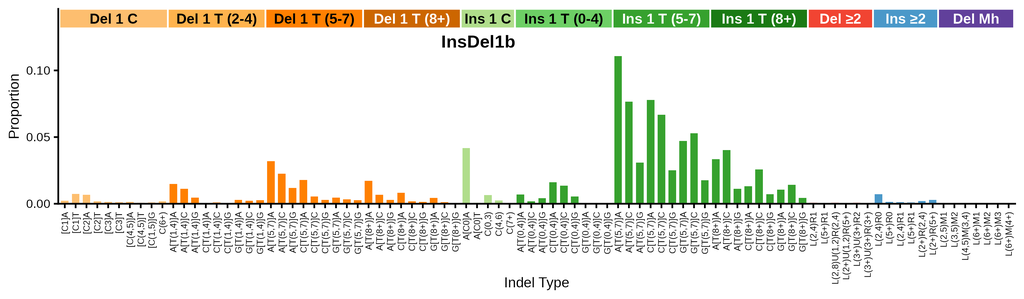

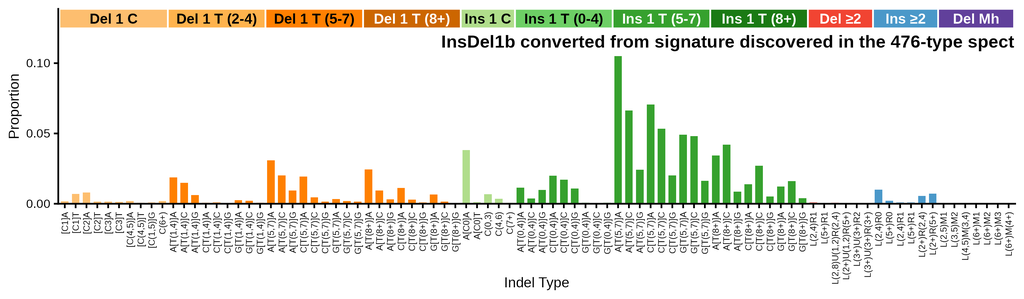

89-type spectrum of the linking tumor SP21400 | cosine similarity to InsDel1b: 0.985

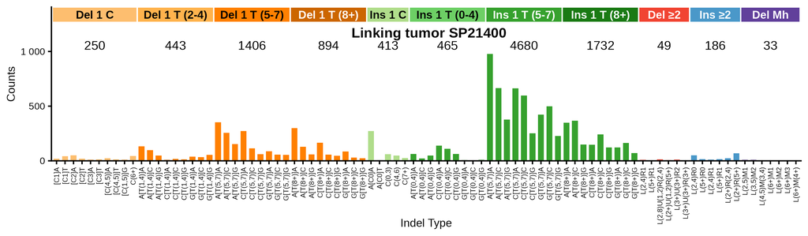

**Click to view decomposition of the linking tumor spectrum**

Partial mutation signature of SP21400 due to InsDel1b

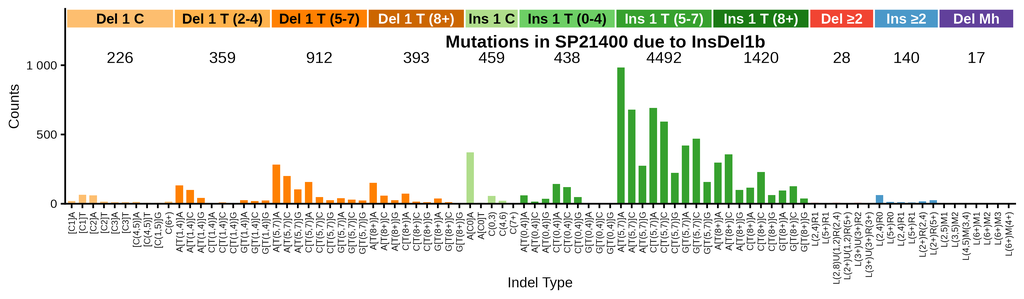

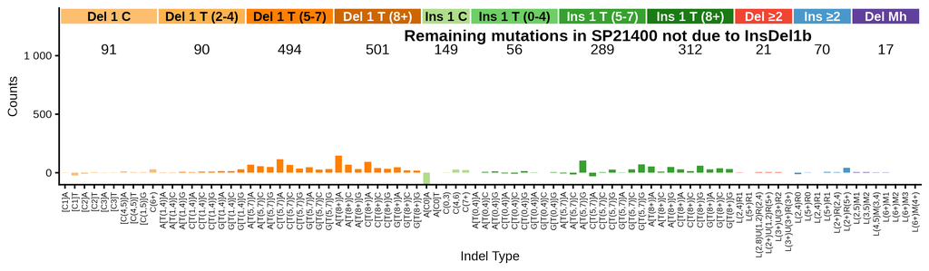

Max neg fraction (maximum allowed negative residual count as fraction of total): 0.02  
N subtract (mutation count assigned to signature): 8885.3  
N residual (mutation count in residual “partial spectrum”): 1665.7  
Total negative (sum of negative residual mutation counts): 211.0  
N negative channels (number of channels with negative residual): 14  
P(≥ total negative) (Monte Carlo estimated probability that negative-binomial-sampled spectra from the signature contributing N subtract mutations would produce a total negative count >= the observed Total negative; higher number means not surprising): 0.995

**Per-channel residual breakdown**

| Channel | Spectrum | Sig_Count | Residual | Sig_Prop |
| --- | --- | --- | --- | --- |
| [Del(C):R1]A | 19 | 20.1 | -1.1 | 0.00226 |
| [Del(C):R1]T | 42 | 64.7 | -22.7 | 0.00728 |
| [Del(C):R2]A | 51 | 60.0 | -9 | 0.00675 |
| [Del(C):R2]T | 20 | 15.5 | 4.5 | 0.00175 |
| [Del(C):R3]A | 11 | 11.7 | -0.7 | 0.00131 |
| [Del(C):R3]T | 13 | 10.6 | 2.4 | 0.00119 |
| [Del(C):R(4,5)]A | 24 | 13.1 | 10.9 | 0.00147 |
| [Del(C):R(4,5)]T | 13 | 7.2 | 5.8 | 0.00081 |
| [Del(C):R(1,5)]G | 12 | 7.7 | 4.3 | 0.00086 |
| Del(C):R(6,9) | 45 | 15.6 | 29.4 | 0.00175 |
| A[Del(T):R(1,4)]A | 132 | 132.6 | -0.6 | 0.01492 |
| A[Del(T):R(1,4)]C | 97 | 99.4 | -2.4 | 0.01119 |
| A[Del(T):R(1,4)]G | 48 | 41.4 | 6.6 | 0.00466 |
| C[Del(T):R(1,4)]A | 10 | 4.8 | 5.2 | 0.00054 |
| C[Del(T):R(1,4)]C | 17 | 8.4 | 8.6 | 0.00094 |
| C[Del(T):R(1,4)]G | 13 | 4.0 | 9 | 0.00045 |
| G[Del(T):R(1,4)]A | 39 | 25.6 | 13.4 | 0.00288 |
| G[Del(T):R(1,4)]C | 33 | 19.2 | 13.8 | 0.00216 |
| G[Del(T):R(1,4)]G | 54 | 23.9 | 30.1 | 0.00269 |
| A[Del(T):R(5,7)]A | 352 | 283.5 | 68.5 | 0.03190 |
| A[Del(T):R(5,7)]C | 255 | 199.5 | 55.5 | 0.02245 |
| A[Del(T):R(5,7)]G | 154 | 104.8 | 49.2 | 0.01179 |
| C[Del(T):R(5,7)]A | 272 | 157.6 | 114.4 | 0.01774 |
| C[Del(T):R(5,7)]C | 114 | 48.3 | 65.7 | 0.00544 |
| C[Del(T):R(5,7)]G | 61 | 25.0 | 36 | 0.00282 |
| G[Del(T):R(5,7)]A | 87 | 40.3 | 46.7 | 0.00454 |
| G[Del(T):R(5,7)]C | 56 | 29.1 | 26.9 | 0.00328 |
| G[Del(T):R(5,7)]G | 55 | 24.1 | 30.9 | 0.00271 |
| A[Del(T):R(8,)]A | 299 | 151.9 | 147.1 | 0.01710 |
| A[Del(T):R(8,)]C | 129 | 59.4 | 69.6 | 0.00668 |

[output cut: 59 more lines]

**Click to view similar signatures from Koh et al.**

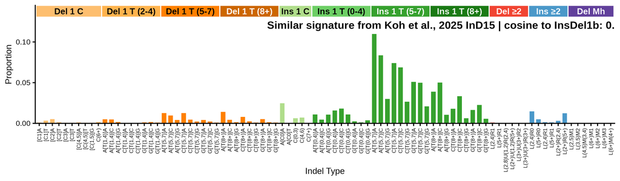

## 476-type representations corresponding to InsDel1b

Extracted 476-type signature corresponding to InsDel1b

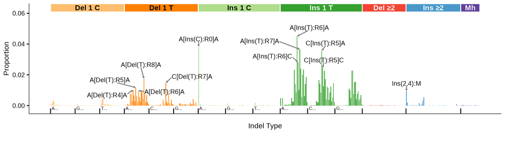

476-type spectrum of the linking tumor SP21400; cosine similarity to the extracted 476-type signature is 0.9701

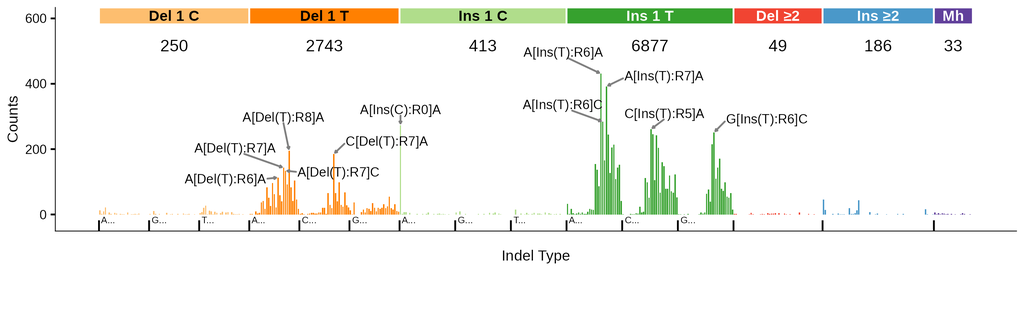

476-type spectrum of best 476-type matching tumor SP16886; cosine similarity to the extracted 476-type signature is 0.9714

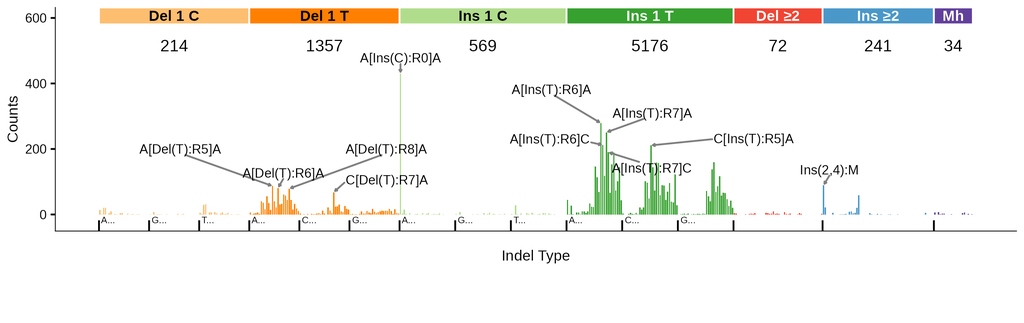

## 83-type signature corresponding to InsDel1b (C_ID1)

**Note**

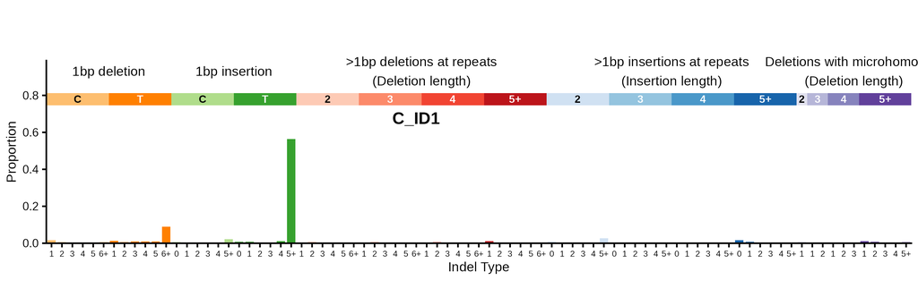

**Click here to see with insertions and deletions of T in long poly-T suppressed**

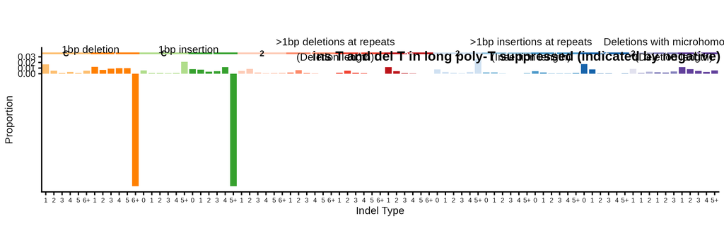

83-type signature converted from signature discovered in the 476-type spectra (using bipartite matching optimization) | cosine similarity to C_ID1: 0.9917

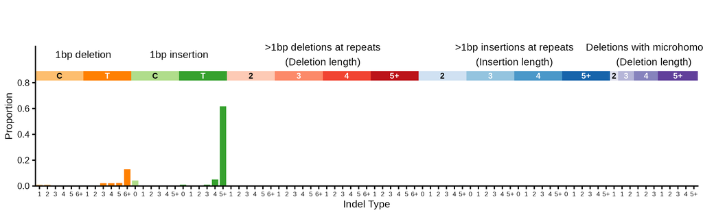

**Click here to see with insertions and deletions of T in long poly-T suppressed**

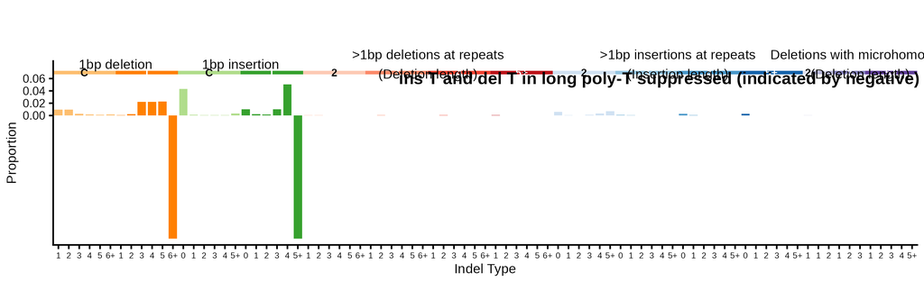

**Click to see flow diagrams: 476-type to 83-type collapse**

These Sankey diagrams show how the 476-type mutation categories are redistributed to 83-type categories using bipartite matching. We only show the diagrams for insertions or deletions of > 1 base because it is for these indels that 476-type categories map to > 1 83-type category.

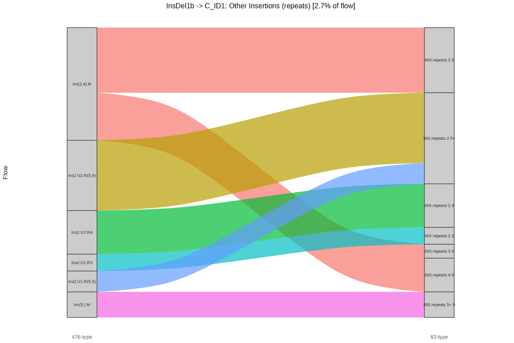

83-type spectrum of the linking tumor SP21400 | cosine similarity to C_ID1: 0.9847

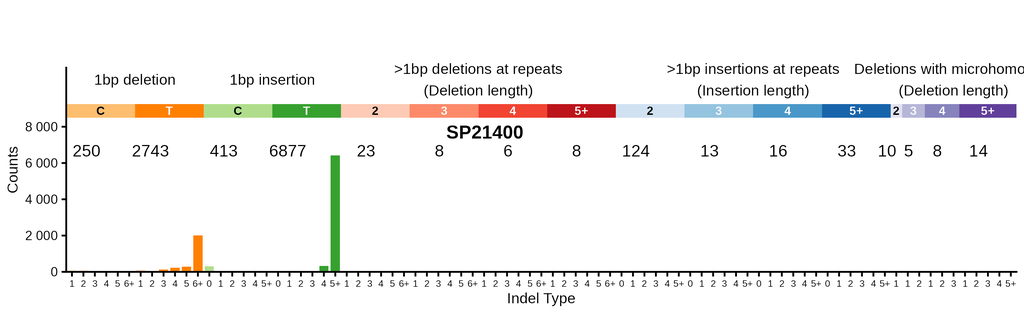

**Click here to see with insertions and deletions of T in long poly-T suppressed**

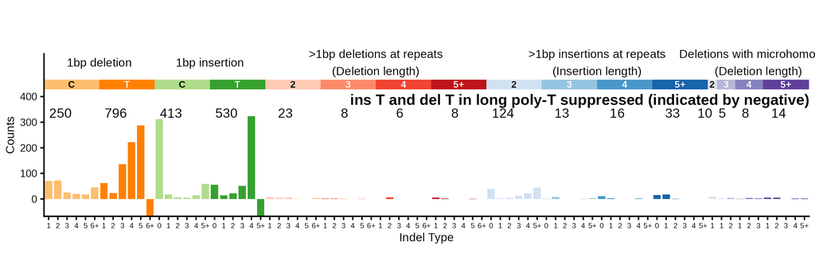

83-type spectrum of best 83-type matching tumor SP107784 | cosine similarity to C_ID1: 0.9986

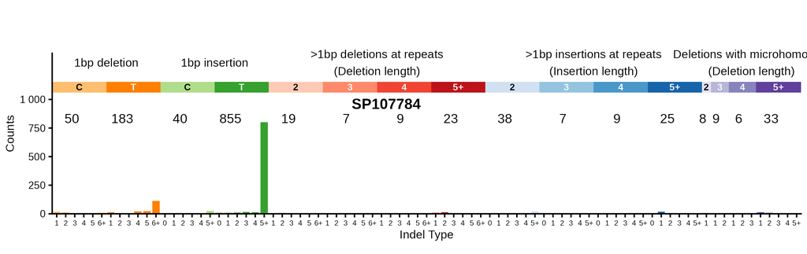

**Click here to see with insertions and deletions of T in long poly-T suppressed**

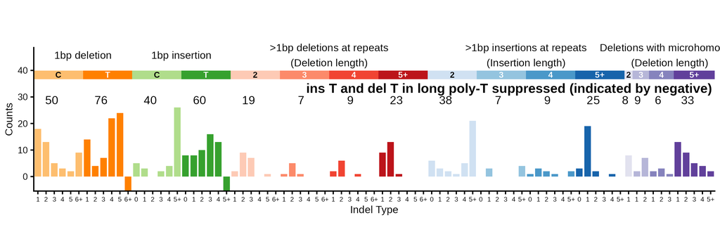

### Similar COSMIC signatures

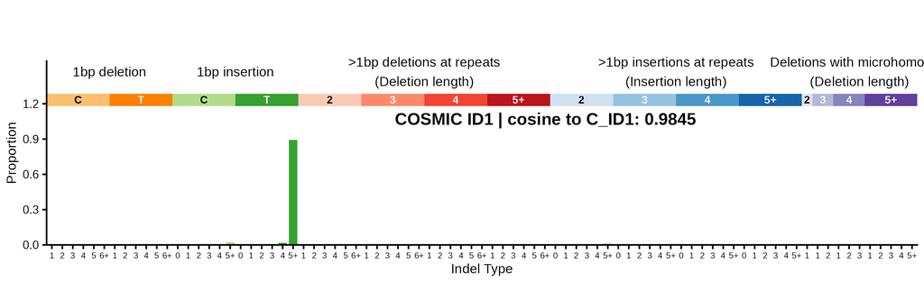

**Click here to see with insertions and deletions of T in long poly-T suppressed**

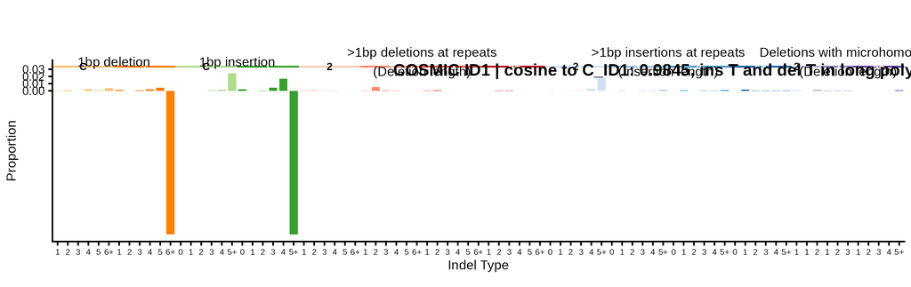

### Similar signatures from Jin et al. 2024

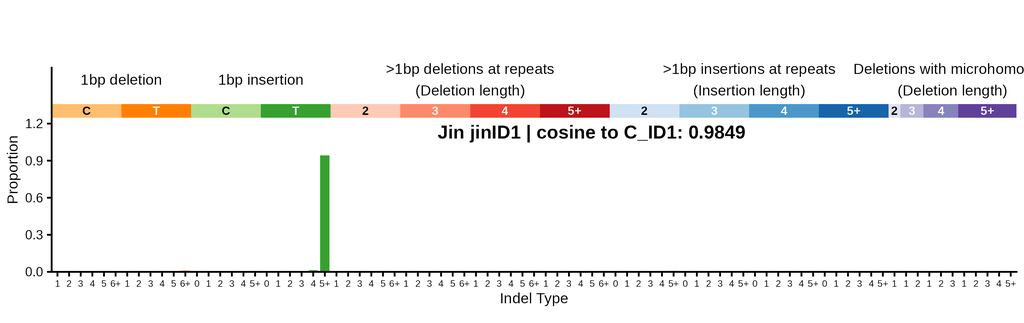

**Click here to see with insertions and deletions of T in long poly-T suppressed**

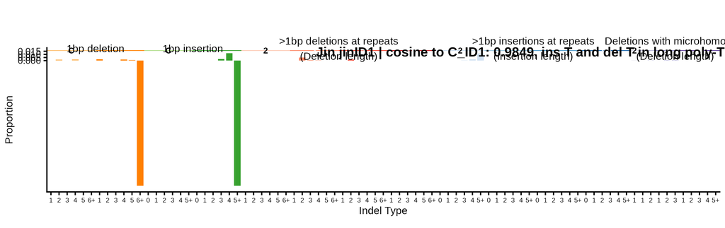